# A data-driven Analysis of Florian Wirtz’s successful season

by Eric Her

# Acknowledgement

The following analysis was done using the 2023/2024 Bundesliga Bayern Leverkusen Dataset presented by Hudl Statsbomb(https://statsbomb.com/articles/soccer/free-statsbomb-data-bayer-leverkusens-invincible-bundesliga-title-win/).

The analysis features the `SBpitch` R-Package and follows a similar structure as the Statsbomb tutorials.

[figure not shown]

Hudl Statsbomb Logo

# Introduction

Bayern Leverkusen had a wonderful season, perhaps the best season ever in their franchise history. Without a single loss in the 2023-2024 regular season, Bayern Leverkusen won 28 games out of 34 regular season games, only tying the rest of their matches.

Although it is hard to conclude who or what drastically changed them from being a mid-table team to a top-tier team, there are some key players and key tactical differences that stand out.

What stood out to me the most is the rise of the 21-year-old German midfielder Florian Wirtz and his versatility in the attacking midfield area, and how he allowed Bayern Leverkusen to have an upper hand in their attacking formation.

Hence, I’ve focused on analyzing his usage and movement in the attacking third.

# Analysis

Before we conduct any analysis, we start by loading all the necessary libraries and dataset from Hudl Statsbomb.

For the actual analysis, I looked at the number of shots recorded by the Bayern Leverkusen players first. I thought this could give me some insights as to how Florian Wirtz is being utilized in the Leverkusen squad. For simplicity, I have `sliced` the data only for the top 10 players with the most shots.

```r
#Group by players' names and ids
Bplayer_shots <- BStatsBombData %>%
  group_by(player.name, player.id) %>%
  #Summarise by the total number of shots by each player
  summarise(shots = sum(type.name == "Shot", na.rm = TRUE)) %>%
  arrange(desc(shots)) %>%
  ungroup() %>%
  slice(1:10)
```

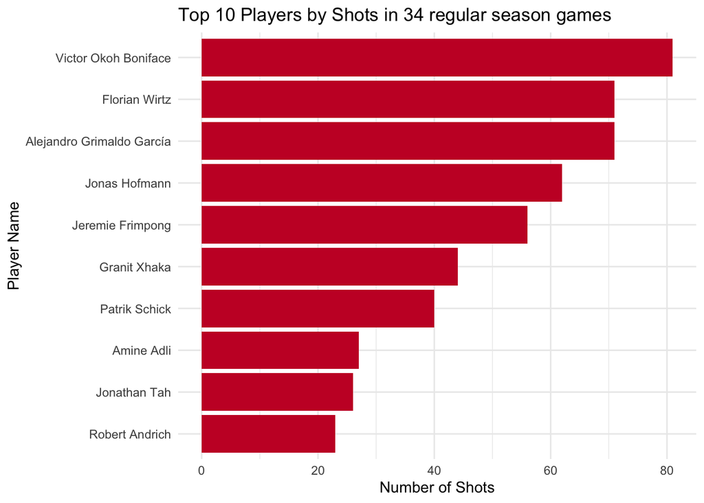

```r
ggplot(Bplayer_shots, aes(x = reorder(player.name, shots), y = shots)) +
  geom_bar(stat = "identity", fill = "#C8102E") +
  labs(title = "Top 10 Players by Shots in 34 regular season games",
       x = "Player Name", y = "Number of Shots") +
  coord_flip() +
  theme_minimal()
```

Florian Wirtz recorded the second most number of shots in the Leverkusen Squad tied with Grimaldo, which happens to be the only two players in 2023/2024 Bundesliga season to join the infamous “10-10 club” (It is a term used in soccer to refer players who scored more than 10 goals and 10 assists in a season).

Now, diving a bit more into the Wirtz’s in-game analysis:

When deciding what metrics to include in this analysis, I decided to start with the visualization of completed through ball passes, as they are highly correlated with creating big chances and considered valuable in the modern-day soccer.

Looking at his completed through balls:

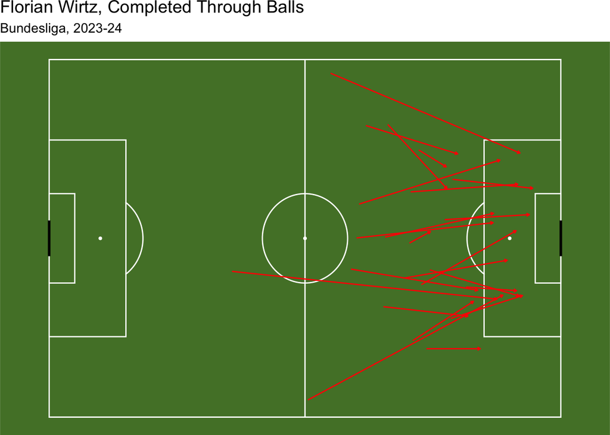

```r
#Wirtz's completed through ball stats
Florian_Wirtz_through = BStatsBombData %>%
  filter(player.id == 40724 & pass.through_ball == TRUE)

#R Package provided by Statsbomb for creating a soccer pitch
create_Pitch(grass_colour = "#538032",
             line_colour =  "#ffffff",
             background_colour = "#538032",
             goal_colour = "#000000") +
  geom_segment(data = Florian_Wirtz_through,
               aes(x = location.x, y = location.y,
                                        xend = pass.end_location.x,
                   yend = pass.end_location.y),
               lineend = "round", size = 0.5, colour = "red",
               arrow = arrow(length = unit(0.03, "inches"),
                             ends = "last", type = "open")) +
  labs(title = "Florian Wirtz, Completed Through Balls",
       subtitle = "Bundesliga, 2023-24") +
  scale_y_reverse() + coord_fixed(ratio = 105/100)
```

The bottom of the arrow indicates where the pass was started (i.e. the coordinate when the ball left the foot) and the tip of the arrow indicates where the passes were received and notice how most of the completed passes are within the “final third”, the awkward zone between the final defender and the goalie, where neither goalie nor the center back have clear access to. We are not able to see the outcome of the completed passes, but can presume they are more likely to be led to creating big chances.

Speaking of creating big chances, here’s a quick visualization of the big chances created by Florian Wirtz.

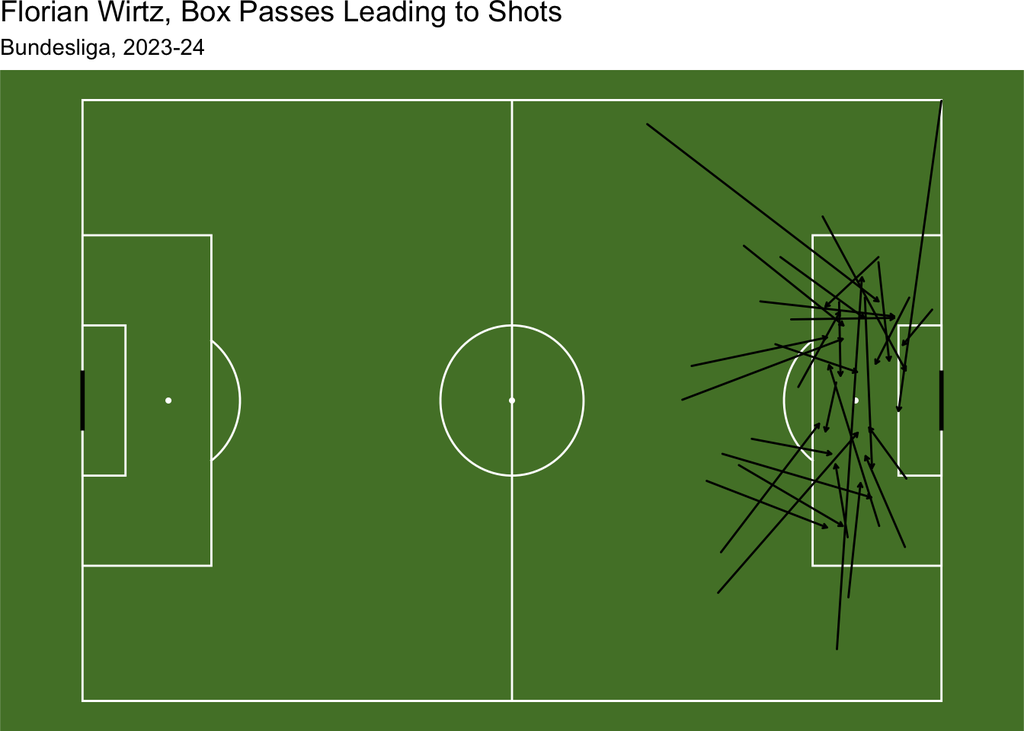

```r
#Wirtz passes into the box which turned into the shots
Wirtz_passes_shots = BStatsBombData %>%
  filter(type.name == "Pass" & is.na(pass.outcome.name)
         & player.id==40724 & pass.shot_assist == TRUE)%>%
  filter(pass.end_location.x>=102 & pass.end_location.y<=62
         & pass.end_location.y>=18)


create_Pitch(grass_colour = "#538032",
             line_colour =  "#ffffff",
             background_colour = "#538032",
             goal_colour = "#000000") +
  geom_segment(data = Wirtz_passes_shots,
               aes(x = location.x, y = location.y,
                                              xend = pass.end_location.x,
                   yend = pass.end_location.y),
               lineend = "round", size = 0.5, colour = "#000000",
               arrow = arrow(length = unit(0.03, "inches"),
                             ends = "last", type = "open")) +
  labs(title = "Florian Wirtz, Box Passes Leading to Shots",
       subtitle = "Bundesliga, 2023-24") +
  scale_y_reverse() + coord_fixed(ratio = 105/100)
```

Similar format but this time, we are analyzing the completed passes which then led to shots. Still, it’s not clear whether the shot was on target or not, this provides a glimpse of the amount of opportunities being created by Wirtz.

After conducting these two analysis, I was able to quickly determine how most of the passes are all coming from different directions, and that they are quite random. Being random in soccer means the player is able to position themselves all across the pitch, cover more area and isolate themselves from the defenders.

His main position in the Left Midfield didn’t limit him from delivering passes all across the field.

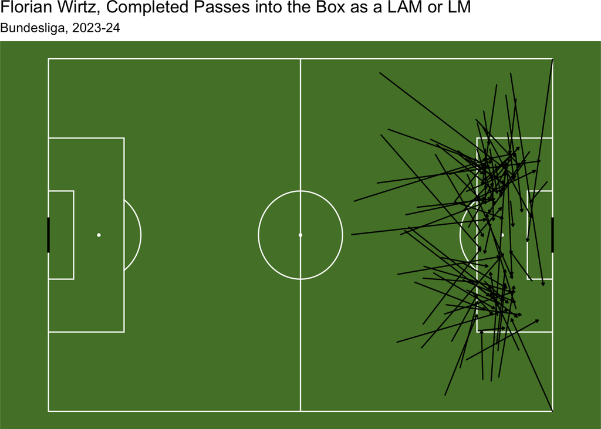

```r
#subset of seeing when he plays only left

Wirtz_passes_left = BStatsBombData %>%
  filter(type.name == "Pass" & is.na(pass.outcome.name) &
           player.id==40724 & position.id >= 20) %>%
  filter(pass.end_location.x>=102 & pass.end_location.y<=62 &
           pass.end_location.y>=18)

create_Pitch(grass_colour = "#538032",
             line_colour =  "#ffffff",
             background_colour = "#538032",
             goal_colour = "#000000") +
  geom_segment(data = Wirtz_passes_left, aes(x = location.x, y = location.y,
                                              xend = pass.end_location.x,
                                             yend = pass.end_location.y),
               lineend = "round", size = 0.5, colour = "#000000",
               arrow = arrow(length = unit(0.03, "inches"),
                             ends = "last", type = "open")) +
  labs(title = "Florian Wirtz, Completed Passes into the Box as a LAM or LM",
  subtitle = "Bundesliga, 2023-24") +
  scale_y_reverse() + coord_fixed(ratio = 105/100)
```

Lastly, I looked at the amount of completed dribbles to measure the effectiveness in his 1v1 skills.

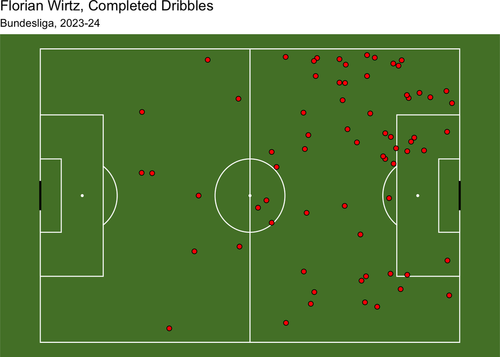

```r
#Florian Wirtz dribbles
Wirtz_dribbles = BStatsBombData %>%
  filter(player.id == 40724 & dribble.outcome.name == "Complete")

create_Pitch(grass_colour = "#538032",
             line_colour =  "#ffffff",
             background_colour = "#538032",
             goal_colour = "#000000") +
  # Plot the dribbles using points
  geom_point(data = Wirtz_dribbles, aes(x = location.x, y = location.y),
             shape = 21, fill = "#FF0000", colour = "#000000", size = 2) +

  # Add titles and labels
  labs(title = "Florian Wirtz, Completed Dribbles",
       subtitle = "Bundesliga, 2023-24") +

  # Reverse the y-axis and fix the aspect ratio
  scale_y_reverse() + coord_fixed(ratio = 105/100)
```

This adds evidence in proving his versataility in the soccer pitch and how his market value went up by 20 Million Euros in single season.

# Conclusion

Florian Wirtz’s presence in the field hugely contributed to Leverkusen’s historic season. His ability to create big chances, deliver passes into the opposing final third and effective dribbling style cemented his role as a young rising star not only within the Leverkusen squad, also in the national world of soccer.